Abalone Age Prediction and Insight Mining

DDS DS 6306 — Project 2

Aayush Dalal & Jacqueline Vu

Fall 2025

1

Abstract

Accurate estimation of abalone age is essential for ﬁsheries management, popula-

tion sustainability, and ecological research, yet traditional age determination methods

require destructive sampling. This project develops interpretable predictive models for

abalone age using physical and biological measur e ments while also extracti ng scientiﬁc

insights into growth behavi or .

Two complementary objectives are addressed. Objective A focuses on prediction,

where a sequence of linear regression–based models is constr u ct ed and evaluated us-

ing Mean Absolute Error (MAE). Startin g f r om a baseline multiple linear regr es si on ,

performance is improved through feature selection, regularization, nonlinear transfor-

mations, and spline basis expansions. A spline–stepwise hybrid model ach i eves the best

predictive accuracy with a test MAE of approximately 1.42 years, while remaining fully

within the linear regression framework.

Objective B emphasizes interpretation and insight mining. Exploratory data anal-

ysis reveals strong nonlinear relationships between age and size-relat ed predictors such

as shell weight, di ame t er , and height. Structural features, including shape ratios and

shell-to-total weight allocation, exhibit meaningful associations wit h age, reﬂecting bi-

ological tradeoﬀs between growth and protection. Sex-speciﬁc gr owth patterns further

highlight diﬀerences between juvenile and adult abalones.

Togeth er , these results demonstrat e that linear regression models, when paired with

thoughtful feature engineering and nonlinear predictor transformations, can achieve

high predictive accuracy while retaining interpretability. The combined modeling and

exploratory approach provides both practical prediction tools and biologically mean-

ingful insights into abalone growth and aging.

1 Introduction

Accurately estimating the age of abalones is an important task in both marine biology and

commercial ﬁsheries. Abalone age provides insight into growth rates, reproductive m at u r i ty,

population sustainability, and environmenta l stressors such as climate change and ocean

pollution. Trad i t i o nal l y, age estimation requires des tr u ct i ve sampling methods, motivating

the need for reliab l e predictive models based on p hysical measurements.

This project addresses two complementary objectives. Objecti ve A focuses on devel-

oping accurate predictive models for abalone age using linear regression–based approaches.

Obj ecti ve B shifts fr o m prediction to interpretation, id entifying the bio l og i ca l and struc-

tural features that most stro n gl y inﬂuence abalone aging.

Together, these objectives balance predictive performance with scientiﬁc insight.

2

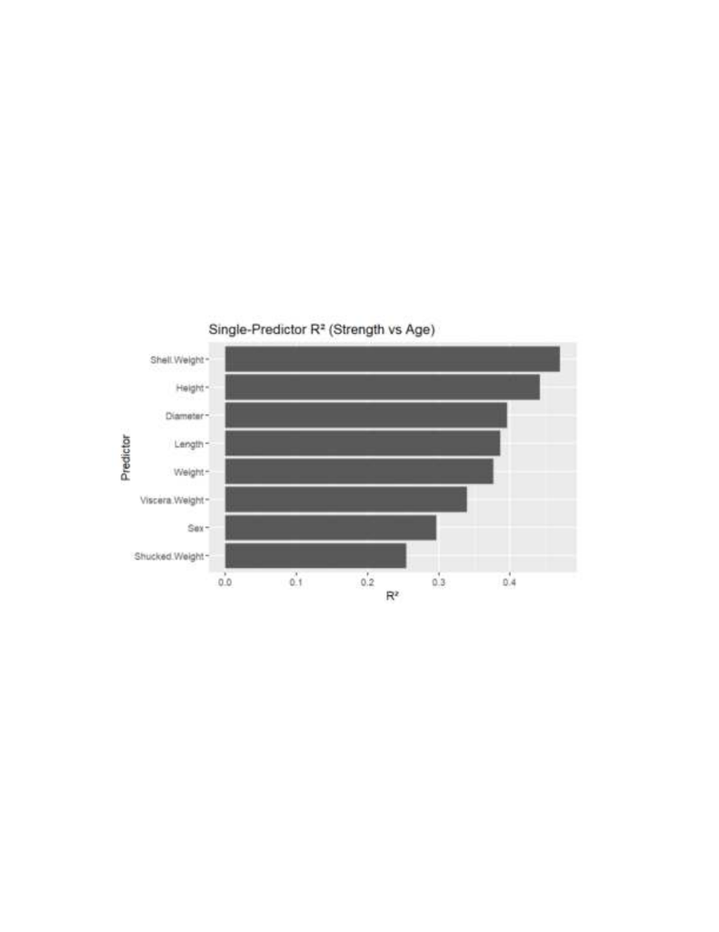

2 Objective A: Predicting Abalone Age

2.1 Modeling Goal and Evaluation Metric

The goal of Objective A is to predict abalone age using physical and biological measurements.

Model performance is evaluated u si n g Mean Absolute Error (MAE), which measu r es the

average absolu t e diﬀerence between predicted and observed ages. MAE is preferred because

it is directly interpretable in units of years and is les s sensitive to extre m e values than

squared-error metrics.

All model s were evaluated using an 80/20 train–t est split with a ﬁxed random seed to

ensure reproducibility.

Figure 1: Single-predictor R

2

values com p a r i n g the strength of indivi d u al predi ct o rs again st

abalone age. This provides a baseline view of w h i ch variables are most informative on their

own.

2.2 Baseline Linear Regression

The modeling process began with a baseline multiple linear regr es si on including all avail-

able predictors: length, diameter, height, total weight, shell weight, shucked weight, viscera

weight, and sex. This model captured genera l trend s but exhibi te d struct u r ed resid ua l pat-

terns, indicating violations of the linearity assumption.

The baseline model achieved a test MAE of approximately 1.44 years, establishing a

benchmark for improvement.

3

2.3 Feature Select io n and Regularization

Stepwise regression using Akaike Infor m a ti o n Criterion (AIC) was applied to improve model

parsimony. While this reduced redundancy, improvements in MAE were modest.

Elastic Net regressio n was also explored to address multicollinearity among correlated

predictors such as length , diameter, and weight. After tuning via cross-validatio n , Elastic

Net produced MAE values similar to stepwise regression, sugg est i n g that nonl i n e ar i ty rather

than collinearity was the dominant source of error.

2.4 Nonlinear Feature Engineering

Exploratory analysis revealed strong nonlinear relati o n sh i p s between age and several pred i c-

tors. To capture these patterns while rema i n i n g within the linear regression fr a m ework, the

following transformations were introduced:

• Logarithmic transformations of weight-related variables,

• Quadratic terms to cap t u r e curvature in growth patterns,

• Interaction terms to encode structural relationships between measurements.

Applying stepwise selection to this expan d ed feature set reduced test MAE to approxi-

mately 1.43 years and improved residual diagnostics.

2.5 Spline-Augmented Linear Regression

Natural spline basis exp a n si o n s were introduced for predictors exhibiting clear curvature,

including diameter, weight, and shell weight. Altho u g h splines introduce nonlinea r transfor-

mations of predictors, the r esu l t i n g model remains linear in its parameters and is therefore

a valid l i n ea r regression model.

Spline-only models performed competitively but did not consistently out perform trans-

formed linear models.

2.6 Spline-Stepwise Hybrid Model

The ﬁnal and best-performing model combined spline terms, polynomial and logarithmic

transformations, biolo gi ca l l y meaningful interactions, and AIC-based stepwi se selection. This

spline-stepwise hybrid model achieved the l owest test MAE of approximately 1.42 years.

The ﬁnal model was reﬁt using all 15,000 traini n g observations and used to generate

predictions for the competition dataset.

4

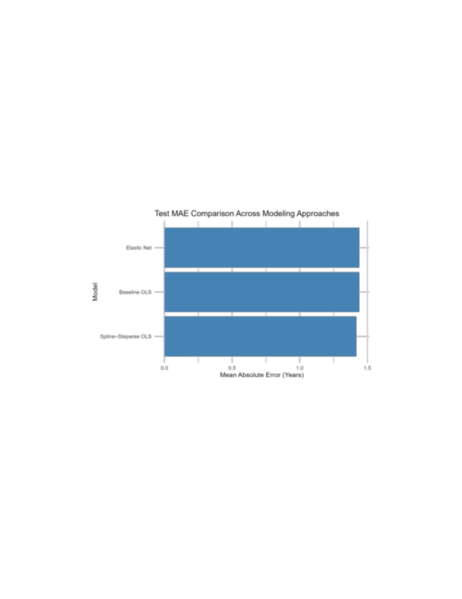

2.7 Why Thes e Models Remain Linear Regression

Despite incorporating nonlinear t ra n sfo r m at i o n s, al l models in Objective A remain linear

regression models because:

• The response is modeled as a linear combination of predictors,

• Transformation s are applied to predictors, not coeﬃcients,

• Estimation is performed via ordinary least squares.

This preserves interpretability whi l e all owing the model to capture complex biological

growth dynamics.

Figure 2: Comparison of test Mean Absolute Er r o r ( MAE) fo r t h r ee m odeling approaches.

While Elastic Net provides regulariz at i o n for correlated predictors, the spline–stepwise linear

regression achieves the lowest MAE by capturing nonlinear growth patterns.

5

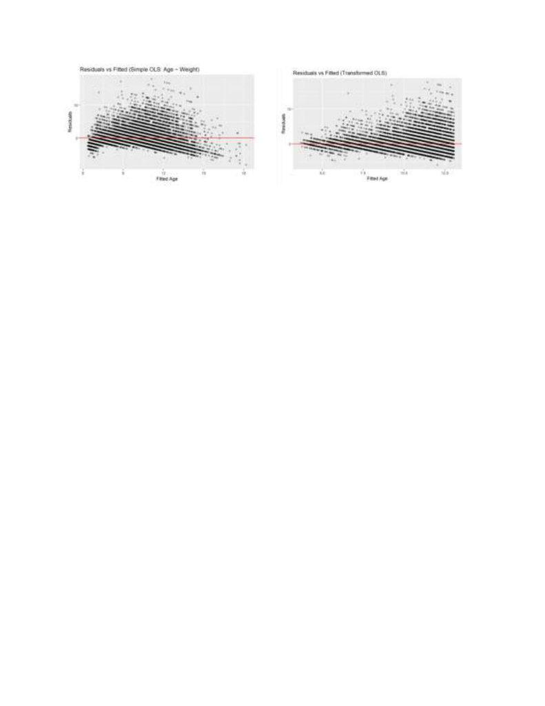

(a) Residuals vs ﬁtted: simple OLS. (b) Residuals vs ﬁtted: transformed OLS.

Figure 3: Residual diagnostics illustrating struc tu r ed err o r und er a naive linear model and

reduced structure after adding nonlinear transformations (still estimated via OLS).

3 Objective B: Mining Data f o r Scientiﬁc Insights

3.1 Purpose o f Objective B

Beyond prediction, Objective B ai ms to identify the biological and structural factors that

drive abalone aging. Understanding these relationships provides insight into growth behavior,

reproductive development, and environmental inﬂuences relevant to ﬁsheries management

and ecological research.

3.2 Data Quality and Structure

The dataset contains 15,00 0 observations with no mi ss in g values and no dupli cat e identiﬁers.

Summary statistics conﬁrm biologically plausib l e ranges for all variabl es , indicatin g hig h dat a

quality.

3.3 Age Distribution and Sex Diﬀe re nces

Abalone age is ri g ht-skewed, with most individuals between 7 and 12 years old. Juvenile

abalones (Sex = I ) are signiﬁcantly younger on average, while males and females exhibit

similar central tendencies with males showing slightly greater variability at older ages.

6

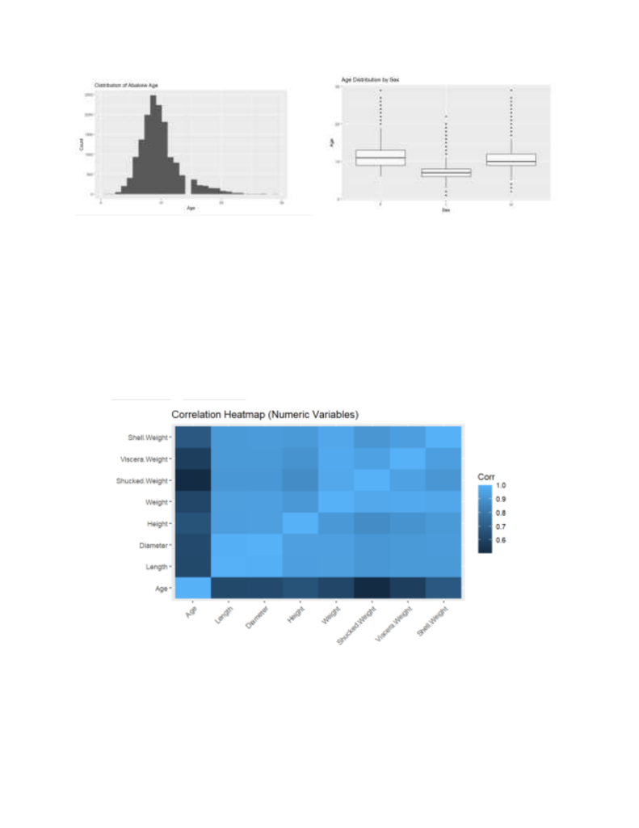

(a) Overall distribution of Age. (b) Age distribution by Sex.

Figure 4: Age distr i b u t i o n overall and stratiﬁed by Sex. Juveniles (I) are younger on average,

while adult groups (F/M) show simil ar centers with diﬀerent tail behavior.

3.4 Correlation Analysis

Correlation analysis reveals that shel l weight has the strongest linear associat i on with age,

followed by height, diamet er , and lengt h . Shucked weight shows a weaker corr el a t i on , sug-

gesting that shell growth is a more reliable indicator of age than edible mass.

Figure 5: Correlation heatmap among numeric predictors and Age. Strong correlations

among size/weight measures suggest multicollinearity and shared “overall size” signal.

7

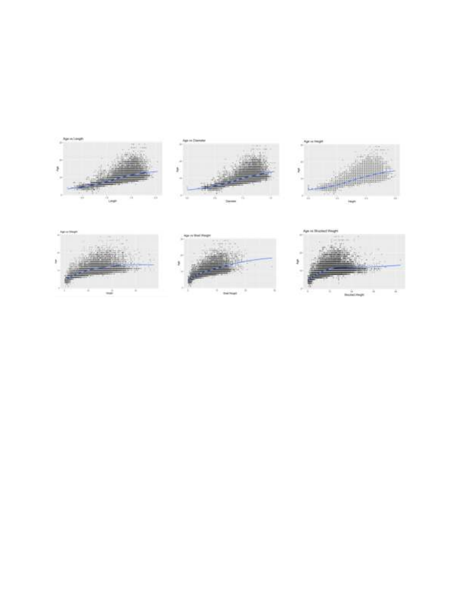

3.5 Nonlinear Growth Patterns

Scatterplots with LOESS smoothers demonstrate nonli n ea r relationships between age and

size-related predictors. Age increases rapidly at smal l e r sizes before leveling oﬀ at larger

values, indicating diminishing marginal growth with age. These patterns explain the perfor-

mance gains ach i e ved by spline and polynom i al terms in Objective A.

(a) Age vs Length. (b) Age vs Diameter. (c) Age vs Height.

(d) Age vs Weight. (e) Age vs Shell.Weight. (f) Age vs Shucked.Weight.

Figure 6: Core growth relationships between Ag e and key size/mass predict or s wit h L OE S S

smoothers, showing curvature and diminishing marginal increases in Age at lar ger sizes.

3.6 Structural and Shape Eﬀects

The ratio of length to diameter captures abalone shape rather than size alon e. Age is

maximized within a moderate range of this ratio, suggesting that abalones with balanced

proportions tend to survive longer than those with e xt r em e shapes.

8

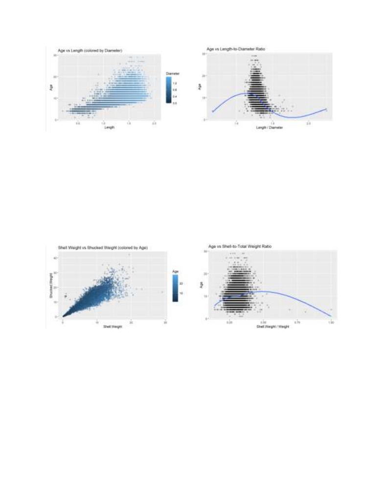

(a) Age vs Length, colored by Diameter. (b) Age vs Length/Diameter ratio.

Figure 7: Shape eﬀects: L eng t h alone is not the full story; diameter and overall pro portions

help explain Age var i at i o n .

3.7 Shell vs Meat Tradeoﬀ

Shell weight and shucked weight are stron gl y correlated, but the shell-to-total weight ratio

to shell growt h , reﬂectin g increased investment in protection and structural integrity.

(a) Shell vs Shucked Weight ( col or ed by Age). (b) Age vs Shell.Weight / Weight.

Figure 8: Tradeoﬀ insight: overall mass and shell allocation shift with Age. The shell-to-

total ratio shows nonlinear behavior consistent with structural investm ent in older abalones.

3.8 Why Nonl ine a r Modeling Is Necessary

error after incorporat i n g nonlinear transformations, justifying their inclusion while remain i n g

within the linear regression framework.

9

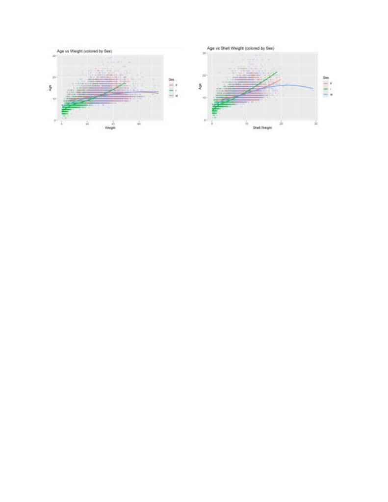

(a) Age vs Weight (colored by Sex). (b) Age vs Shell.Weight (col ore d by Sex).

Figure 9: Sex-speciﬁc d i ﬀe re n ces in the Age–si ze relationship. Juveniles (I) show distinct

patterns from adult classes, m o t i vat i n g interaction and nonlinea r terms in modeling.

3.9 Key Insights from Objective B

Shell weight, height, diameter, and overall body mass are the strongest determinants of

abalone age. Shape, structural investment, and sex-speci ﬁ c growth pat t er n s also contribute

meaningfully t o age variation. These insights a l i gn with biological expectations and support

the modeling decisions made in Objective A.

4 Conclusion

This project demons tr at es t h a t linear regression, when paired with thoughtful feature en-

gineering and n o n l i nea r transformations, can achieve strong predictive performance while

remaining i nterpretable. Objective A delivers a highly accurate age prediction model, while

Objective B provides m ea n i n gfu l biological insights into abalone growth and aging. Together,

these objectives illustr a t e the value of combining predict i ve modeling wi t h exploratory data

analysis in applied data science.

10